# Tech 1. Imputation of values

Nate Breznau, Christine Hedde - von Westernhagen

19/04/21

This dataframe was worked up by running the files in the */src* folder.

```r
df_raw <- readRDS(here::here("output/joined_raw_owd.Rds"))

df_raw <- df_raw %>%
  filter(!is.na(country)) %>%
  filter(country != "Northern Mariana Islands")
```

After compiling data for our target variables many missing values remain. We use three types of information.

1. Within-country linear trends

To use this we need a variable that has sporadic missing or not too many years of missing, ideally in-between values rather than at the tails of values. The variable must measure something stable and rather linear.

**Female labor force participation**

2. Within and between-country linear trends

We use both linear and global information for variables like **GDP** that are highly dependent on global economics.

3. (Stochastic) Full-Information Imputation

Some values are missing for large segments of time (like a decade or more, or a large percentage of the total observation points in a country), or are not necessarily linear, like **marriage rates**.

# Calculate Missing %

```r
# get ratio of missing to total values
df_sum <- df_raw %>%
  group_by(country) %>%
  summarise(regime_m = sum(is.na(regime))/length(regime),
            gini_m = sum(is.na(gini_disp))/length(gini_disp),
            gdp_m = sum(is.na(gdp_cap))/length(gdp_cap),
            gdp_mad_m = sum(is.na(gdp_madki))/length(gdp_madki),
            alc_all_m = sum(is.na(alc_all_types))/length(alc_all_types),
            unemp_nat_m = sum(is.na(unemp_nat))/length(unemp_nat),
            unemp_ilo_m = sum(is.na(unemp_ilo))/length(unemp_ilo),
            fertility_m = sum(is.na(fertility))/length(fertility),
            fem_labour_m = sum(is.na(fem_labour))/length(fem_labour),
            crisis_idx_m = sum(is.na(crisis_idx))/length(crisis_idx),
            hh_1member_m = sum(is.na(`1_member`))/length(`1_member`),
            christpct_m = sum(is.na(christpct_i))/length(christpct_i),
            marit_rate_men_m = sum(is.na(marit_rate_men))/length(marit_rate_men),
            marit_rate_women_m = sum(is.na(marit_rate_women))/length(marit_rate_women),
            div_rate_female_m = sum(is.na(div_rate_female))/length(div_rate_female),
            div_rate_male_m = sum(is.na(div_rate_male))/length(div_rate_male),
            year_min = min(year),
            year_max = max(year),
            year_mean = mean(year),
            cases = n()) %>%
  ungroup() %>%
  rowwise() %>%
  mutate(missing_avg = mean(c_across(-c(country, year_min, year_max, year_mean, cases)))) %>%
  select(country, missing_avg, everything()) %>%
  arrange(desc(missing_avg))

# round
#df_sum[,2:ncol(df_sum)] <- round(df_sum[,2:ncol(df_sum)],2)

# table
kable(df_sum, digits = 2) %>%
  kable_classic()
```

| country | missing_avg | regime_m | gini_m | gdp_m | gdp_mad_m | alc_all_m | unemp_nat_m | unemp_ilo_m | fertility_m | fem_labour_m | crisis_idx_m | hh_1member_m | christpct_m | marit_rate_men_m | marit_rate_women_m | div_rate_female_m | div_rate_male_m | year_min | year_max | year_mean | cases |
| --- | --- | --- | --- | --- | --- | --- | --- | --- | --- | --- | --- | --- | --- | --- | --- | --- | --- | --- | --- | --- | --- |
| American Samoa | 0.86 | 1.00 | 1.00 | 0.45 | 0.48 | 1.00 | 0.86 | 1.00 | 1.00 | 1.00 | 1.00 | 1.00 | 0.07 | 0.97 | 0.97 | 0.97 | 0.97 | 1989 | 2017 | 2003 | 29 |
| Marshall Islands | 0.80 | 1.00 | 1.00 | 0.00 | 0.03 | 1.00 | 0.93 | 1.00 | 0.83 | 1.00 | 1.00 | 1.00 | 0.07 | 0.97 | 0.97 | 0.97 | 0.97 | 1989 | 2017 | 2003 | 29 |
| Taiwan | 0.75 | 1.00 | 0.00 | 1.00 | 0.00 | 1.00 | 1.00 | 1.00 | 1.00 | 1.00 | 0.03 | 1.00 | 0.07 | 0.93 | 0.93 | 1.00 | 1.00 | 1989 | 2017 | 2003 | 29 |
| Bermuda | 0.74 | 1.00 | 1.00 | 0.00 | 0.17 | 1.00 | 0.79 | 1.00 | 0.34 | 1.00 | 1.00 | 0.93 | 0.07 | 0.86 | 0.86 | 0.93 | 0.93 | 1989 | 2017 | 2003 | 29 |
| Andorra | 0.73 | 1.00 | 0.45 | 0.00 | 0.03 | 0.38 | 1.00 | 1.00 | 0.83 | 1.00 | 1.00 | 1.00 | 0.07 | 1.00 | 1.00 | 1.00 | 1.00 | 1989 | 2017 | 2003 | 29 |
| Dominica | 0.70 | 1.00 | 0.69 | 0.00 | 0.00 | 0.03 | 0.83 | 1.00 | 0.86 | 1.00 | 1.00 | 1.00 | 0.07 | 0.93 | 0.93 | 0.97 | 0.97 | 1989 | 2017 | 2003 | 29 |
| Micronesia (Federated States of) | 0.69 | 1.00 | 1.00 | 0.00 | 0.03 | 0.00 | 0.97 | 1.00 | 0.00 | 1.00 | 1.00 | 1.00 | 0.07 | 1.00 | 1.00 | 0.97 | 0.97 | 1989 | 2017 | 2003 | 29 |
| U.S. Virgin Islands | 0.69 | 1.00 | 1.00 | 0.45 | 0.52 | 1.00 | 1.00 | 0.07 | 0.00 | 0.03 | 1.00 | 1.00 | 0.07 | 0.93 | 0.93 | 1.00 | 1.00 | 1989 | 2017 | 2003 | 29 |
| Antigua & Barbuda | 0.68 | 1.00 | 0.97 | 0.00 | 0.03 | 0.00 | 0.93 | 1.00 | 0.00 | 1.00 | 1.00 | 1.00 | 0.07 | 0.93 | 0.93 | 1.00 | 1.00 | 1989 | 2017 | 2003 | 29 |
| South Sudan | 0.67 | 0.24 | 0.97 | 0.72 | 1.00 | 1.00 | 0.97 | 0.07 | 0.00 | 0.03 | 1.00 | 0.97 | 0.07 | 0.90 | 0.86 | 1.00 | 1.00 | 1989 | 2017 | 2003 | 29 |
| Kiribati | 0.66 | 1.00 | 0.97 | 0.00 | 0.03 | 0.00 | 0.90 | 1.00 | 0.00 | 1.00 | 1.00 | 1.00 | 0.07 | 0.83 | 0.83 | 1.00 | 1.00 | 1989 | 2017 | 2003 | 29 |
| Grenada | 0.65 | 1.00 | 0.62 | 0.00 | 0.03 | 0.03 | 0.76 | 1.00 | 0.00 | 1.00 | 1.00 | 1.00 | 0.07 | 0.97 | 0.97 | 1.00 | 1.00 | 1989 | 2017 | 2003 | 29 |
| Guam | 0.64 | 1.00 | 1.00 | 0.45 | 0.48 | 1.00 | 0.10 | 0.07 | 0.00 | 0.03 | 1.00 | 1.00 | 0.07 | 1.00 | 1.00 | 1.00 | 1.00 | 1989 | 2017 | 2003 | 29 |
| Seychelles | 0.64 | 1.00 | 0.48 | 0.00 | 0.00 | 0.00 | 0.72 | 1.00 | 0.24 | 1.00 | 1.00 | 0.93 | 0.07 | 0.93 | 0.93 | 0.93 | 0.93 | 1989 | 2017 | 2003 | 29 |
| Eritrea | 0.60 | 1.00 | 1.00 | 0.31 | 0.31 | 0.00 | 1.00 | 0.07 | 0.00 | 0.03 | 1.00 | 1.00 | 0.07 | 0.90 | 0.90 | 1.00 | 1.00 | 1989 | 2017 | 2003 | 29 |
| Greenland | 0.59 | 1.00 | 0.45 | 0.00 | 0.07 | 1.00 | 0.41 | 1.00 | 0.00 | 1.00 | 1.00 | 1.00 | 0.07 | 0.48 | 0.48 | 0.76 | 0.76 | 1989 | 2017 | 2003 | 29 |
| North Korea | 0.58 | 0.24 | 1.00 | 1.00 | 0.03 | 0.00 | 1.00 | 0.07 | 0.00 | 0.03 | 1.00 | 0.97 | 0.07 | 0.97 | 0.97 | 1.00 | 1.00 | 1989 | 2017 | 2003 | 29 |
| Somalia | 0.58 | 0.24 | 0.97 | 1.00 | 0.00 | 0.00 | 1.00 | 0.07 | 0.00 | 0.03 | 1.00 | 1.00 | 0.07 | 1.00 | 0.97 | 1.00 | 1.00 | 1989 | 2017 | 2003 | 29 |
| Brunei | 0.55 | 1.00 | 1.00 | 0.00 | 0.03 | 0.03 | 0.90 | 0.07 | 0.00 | 0.03 | 1.00 | 0.97 | 0.07 | 0.93 | 0.93 | 0.93 | 0.93 | 1989 | 2017 | 2003 | 29 |
| Vanuatu | 0.54 | 1.00 | 0.83 | 0.00 | 0.03 | 0.00 | 0.90 | 0.07 | 0.00 | 0.03 | 1.00 | 1.00 | 0.07 | 0.90 | 0.86 | 0.97 | 0.97 | 1989 | 2017 | 2003 | 29 |
| Maldives | 0.54 | 1.00 | 0.48 | 0.21 | 0.21 | 0.38 | 0.83 | 0.07 | 0.00 | 0.03 | 1.00 | 0.90 | 0.07 | 0.83 | 0.79 | 0.90 | 0.90 | 1989 | 2017 | 2003 | 29 |
| Libya | 0.53 | 0.24 | 0.79 | 0.34 | 0.00 | 0.00 | 0.97 | 0.07 | 0.00 | 0.03 | 1.00 | 1.00 | 0.07 | 0.97 | 0.97 | 1.00 | 1.00 | 1989 | 2017 | 2003 | 29 |
| Syria | 0.53 | 0.24 | 0.62 | 1.00 | 0.00 | 0.00 | 0.52 | 0.07 | 0.00 | 0.03 | 1.00 | 1.00 | 0.07 | 0.97 | 0.93 | 1.00 | 1.00 | 1989 | 2017 | 2003 | 29 |
| Afghanistan | 0.52 | 0.24 | 0.62 | 0.45 | 0.00 | 0.17 | 0.86 | 0.07 | 0.00 | 0.03 | 1.00 | 0.97 | 0.07 | 0.97 | 0.90 | 1.00 | 1.00 | 1989 | 2017 | 2003 | 29 |
| Djibouti | 0.52 | 0.24 | 0.24 | 0.97 | 0.00 | 0.00 | 0.97 | 0.07 | 0.00 | 0.03 | 1.00 | 1.00 | 0.07 | 0.90 | 0.86 | 1.00 | 1.00 | 1989 | 2017 | 2003 | 29 |
| São Tomé & Príncipe | 0.52 | 1.00 | 0.38 | 0.41 | 0.00 | 0.00 | 0.72 | 0.07 | 0.00 | 0.03 | 1.00 | 0.93 | 0.07 | 0.90 | 0.83 | 0.97 | 0.97 | 1989 | 2017 | 2003 | 29 |
| Equatorial Guinea | 0.52 | 0.24 | 0.97 | 0.00 | 0.00 | 0.00 | 1.00 | 0.07 | 0.00 | 0.03 | 1.00 | 1.00 | 0.07 | 0.93 | 0.93 | 1.00 | 1.00 | 1989 | 2017 | 2003 | 29 |
| Palestinian Territories | 0.52 | 1.00 | 0.28 | 0.17 | 0.00 | 1.00 | 0.38 | 0.07 | 0.03 | 0.03 | 1.00 | 0.93 | 0.07 | 0.83 | 0.72 | 0.86 | 0.86 | 1989 | 2017 | 2003 | 29 |
| St. Vincent & Grenadines | 0.52 | 1.00 | 0.52 | 0.00 | 0.03 | 0.03 | 0.90 | 0.07 | 0.00 | 0.03 | 1.00 | 1.00 | 0.07 | 0.86 | 0.86 | 0.93 | 0.93 | 1989 | 2017 | 2003 | 29 |
| Montenegro | 0.51 | 0.24 | 0.59 | 0.28 | 0.00 | 0.59 | 0.59 | 0.07 | 0.00 | 0.03 | 1.00 | 0.97 | 0.07 | 0.90 | 0.86 | 1.00 | 1.00 | 1989 | 2017 | 2003 | 29 |

[output cut: 164 more lines]

# Imputation

## Impute GDP pre linear

Step 1. World Bank interpolation

Using a regression approach we can approximate GDP using both within country trends and global trends

Use World Bank GDP to predict Maddison (plus interpolated). There are very few cases that this applies.

Now GDP is ready for interpolation as above

```r
step1 <- lm(gdp_madki ~ gdp_cap + year + gdp_cap*year + iso3c, data = df_raw)

df_raw2 <- df_raw %>%
  filter(iso3c != "PRK" & iso3c != "SOM" & iso3c != "SSD" & iso3c != "SYR" & iso3c != "TWN")

df_raw2$gdp_madkiI <- predict(step1, newdata = df_raw2)

# these countries have no data for gdp_cap
df_raw3 <- df_raw %>%
  filter(iso3c == "PRK" | iso3c == "SOM" | iso3c == "SSD" | iso3c == "SYR" | iso3c == "TWN")


df_raw2 <- df_raw2 %>%
  mutate(gdp_madki_i = ifelse(is.na(gdp_madki), gdp_madkiI, gdp_madki))

df_raw2 <- select(df_raw2, -c(gdp_madkiI))

df_raw3$gdp_madki_i <- df_raw3$gdp_madki

df_raw <- rbind(df_raw2, df_raw3)
```

## Within-Country Linear Trends

ideally countries variables with 20% or less missing per country for gini, fem labor force participation, fertility, alcohol consumption.

Regime can impute years when the government is ‘missing’ (war usually)

```r
# select cases
flp15 <- df_sum$country[df_sum$fem_labour_m > 0 & df_sum$fem_labour_m<0.21]
gini15 <- df_sum$country[df_sum$gini_m > 0 & df_sum$gini_m<0.21]
fert15 <- df_sum$country[df_sum$fertility_m > 0 & df_sum$fertility_m<0.21]
alc15 <- df_sum$country[df_sum$alc_all_m > 0 & df_sum$alc_all_m<0.21]
regime15 <- df_sum$country[df_sum$regime_m > 0 & df_sum$regime_m<0.4] # regime is quite stable
gdp15 <- df_sum$country[df_sum$gdp_cap_m > 0 & df_sum$gdp_cap_m<0.5] # we do this to account for the step 1 above (a larger margin allowed)


# impute linearly for these cases
# first make sure cases are ordered by year
df_imp <- df_raw %>%
  group_by(country) %>%
  arrange(., year, .by_group = T) %>%
          #We have a few cases from unemp_ilo that exist when unemp_nat is missing.
          #We can fill these in as our 'next best guess'.
  mutate(unemp_i = ifelse(is.na(unemp_nat),unemp_ilo, unemp_nat),
         unemp_i = ifelse(is.na(unemp_nat), NA, unemp_i),

         fem_labour_i = ifelse(country %in% flp15,
                               na_interpolation(fem_labour),
                               fem_labour),

         gini_disp_i = ifelse(country %in% gini15,
                              na_interpolation(gini_disp),
                              gini_disp),

         fertility_i = ifelse(country %in% fert15,
                              na_interpolation(fertility),
                              fertility),

         regime_i = ifelse(country %in% regime15,
                              na_interpolation(regime),
                              regime),
         gdp_cap_i = ifelse(country %in% gdp15,
                            na_interpolation(gdp_madki_i),
                            gdp_madki_i),

         christpct_ii = ifelse(is.na(christpct_i), na_interpolation(christpct_i), christpct_i),
         islampct_ii = ifelse(is.na(islampct_i), na_interpolation(islampct_i), islampct_i),
         buddhapct_ii = ifelse(is.na(buddhapct_i), na_interpolation(buddhapct_i), buddhapct_i),
         jewishpct_ii = ifelse(is.na(jewishpct_i), na_interpolation(jewishpct_i), jewishpct_i),
         hindupct_ii = ifelse(is.na(hindupct_i), na_interpolation(hindupct_i), hindupct_i),
         otherpct_ii = ifelse(is.na(otherpct_i), na_interpolation(otherpct_i), otherpct_i),
         nonreligpct_ii = ifelse(is.na(nonreligpct_i), na_interpolation(nonreligpct_i), nonreligpct_i),


         alc_all_types_i = ifelse(country %in% alc15,
                                  na_interpolation(alc_all_types),
                                  alc_all_types)) %>%

  select(country, iso3c, year, unemp_nat, unemp_ilo, unemp_i, regime, regime_i, fem_labour, fem_labour_i, gini_disp, gini_disp_i, gdp_madki, gdp_madki_i, gdp_cap_i, fertility, fertility_i, alc_all_types, alc_all_types_i, christpct_i, christpct_ii, islampct_i, islampct_ii, buddhapct_i, buddhapct_ii, jewishpct_i, jewishpct_ii, hindupct_i, hindupct_ii, otherpct_i, otherpct_ii, nonreligpct_i, nonreligpct_ii, suicide_total_m, suicide_total_f, suicide_rate_female_owd, suicide_rate_male_owd, suicide_rate_total_owd, gdp_madki, pop, pop65, crisis_idx, marit_rate_men, marit_rate_women, div_rate_female, div_rate_male, atwar) %>%
  ungroup()
```

## Missing Data after safely interpolated trend values

```r
# get ratio of missing to total values
df_sum2 <- df_imp %>%
  group_by(country) %>%
  summarise(regime_m = sum(is.na(regime_i))/length(regime_i),
            gini_m = sum(is.na(gini_disp_i))/length(gini_disp_i),
            gdp_cap_m = sum(is.na(gdp_cap_i))/length(gdp_cap_i),
            alc_all_m = sum(is.na(alc_all_types_i))/length(alc_all_types_i),
            unemp_m = sum(is.na(unemp_i))/length(unemp_i),
            fertility_m = sum(is.na(fertility_i))/length(fertility_i),
            fem_labour_m = sum(is.na(fem_labour_i))/length(fem_labour_i),
            crisis_idx_m = sum(is.na(crisis_idx))/length(crisis_idx),
            christpct_m = sum(is.na(christpct_ii))/length(christpct_ii),
            marit_rate_men_m = sum(is.na(marit_rate_men))/length(marit_rate_men),
            marit_rate_women_m = sum(is.na(marit_rate_women))/length(marit_rate_women),
            div_rate_female_m = sum(is.na(div_rate_female))/length(div_rate_female),
            div_rate_male_m = sum(is.na(div_rate_male))/length(div_rate_male),
            year_min = min(year),
            year_max = max(year),
            year_mean = mean(year),
            cases = n()) %>%
  ungroup() %>%
  rowwise() %>%
  mutate(missing_avg = mean(c_across(-c(country, year_min, year_max, year_mean, cases)))) %>%
  select(country, missing_avg, everything()) %>%
  arrange(desc(missing_avg))

# table
kable(df_sum2, digits = 2) %>%
  kable_classic()
```

| country | missing_avg | regime_m | gini_m | gdp_cap_m | alc_all_m | unemp_m | fertility_m | fem_labour_m | crisis_idx_m | christpct_m | marit_rate_men_m | marit_rate_women_m | div_rate_female_m | div_rate_male_m | year_min | year_max | year_mean | cases |
| --- | --- | --- | --- | --- | --- | --- | --- | --- | --- | --- | --- | --- | --- | --- | --- | --- | --- | --- |
| American Samoa | 0.86 | 1 | 1.00 | 0.45 | 1.00 | 0.86 | 1.00 | 1 | 1.00 | 0 | 0.97 | 0.97 | 0.97 | 0.97 | 1989 | 2017 | 2003 | 29 |
| Marshall Islands | 0.82 | 1 | 1.00 | 0.00 | 1.00 | 0.93 | 0.83 | 1 | 1.00 | 0 | 0.97 | 0.97 | 0.97 | 0.97 | 1989 | 2017 | 2003 | 29 |
| Bermuda | 0.75 | 1 | 1.00 | 0.00 | 1.00 | 0.79 | 0.34 | 1 | 1.00 | 0 | 0.86 | 0.86 | 0.93 | 0.93 | 1989 | 2017 | 2003 | 29 |
| Andorra | 0.74 | 1 | 0.45 | 0.00 | 0.38 | 1.00 | 0.83 | 1 | 1.00 | 0 | 1.00 | 1.00 | 1.00 | 1.00 | 1989 | 2017 | 2003 | 29 |
| U.S. Virgin Islands | 0.72 | 1 | 1.00 | 0.45 | 1.00 | 1.00 | 0.00 | 0 | 1.00 | 0 | 0.93 | 0.93 | 1.00 | 1.00 | 1989 | 2017 | 2003 | 29 |
| Dominica | 0.71 | 1 | 0.69 | 0.00 | 0.00 | 0.83 | 0.86 | 1 | 1.00 | 0 | 0.93 | 0.93 | 0.97 | 0.97 | 1989 | 2017 | 2003 | 29 |
| Micronesia (Federated States of) | 0.68 | 1 | 1.00 | 0.00 | 0.00 | 0.97 | 0.00 | 1 | 1.00 | 0 | 1.00 | 1.00 | 0.97 | 0.97 | 1989 | 2017 | 2003 | 29 |
| Taiwan | 0.68 | 1 | 0.00 | 0.00 | 1.00 | 1.00 | 1.00 | 1 | 0.03 | 0 | 0.93 | 0.93 | 1.00 | 1.00 | 1989 | 2017 | 2003 | 29 |
| Antigua & Barbuda | 0.67 | 1 | 0.97 | 0.00 | 0.00 | 0.93 | 0.00 | 1 | 1.00 | 0 | 0.93 | 0.93 | 1.00 | 1.00 | 1989 | 2017 | 2003 | 29 |
| South Sudan | 0.67 | 0 | 0.97 | 1.00 | 1.00 | 0.97 | 0.00 | 0 | 1.00 | 0 | 0.90 | 0.86 | 1.00 | 1.00 | 1989 | 2017 | 2003 | 29 |
| Guam | 0.66 | 1 | 1.00 | 0.45 | 1.00 | 0.10 | 0.00 | 0 | 1.00 | 0 | 1.00 | 1.00 | 1.00 | 1.00 | 1989 | 2017 | 2003 | 29 |
| Kiribati | 0.66 | 1 | 0.97 | 0.00 | 0.00 | 0.90 | 0.00 | 1 | 1.00 | 0 | 0.83 | 0.83 | 1.00 | 1.00 | 1989 | 2017 | 2003 | 29 |
| Grenada | 0.64 | 1 | 0.62 | 0.00 | 0.00 | 0.76 | 0.00 | 1 | 1.00 | 0 | 0.97 | 0.97 | 1.00 | 1.00 | 1989 | 2017 | 2003 | 29 |
| Seychelles | 0.63 | 1 | 0.48 | 0.00 | 0.00 | 0.72 | 0.24 | 1 | 1.00 | 0 | 0.93 | 0.93 | 0.93 | 0.93 | 1989 | 2017 | 2003 | 29 |
| Eritrea | 0.62 | 1 | 1.00 | 0.31 | 0.00 | 1.00 | 0.00 | 0 | 1.00 | 0 | 0.90 | 0.90 | 1.00 | 1.00 | 1989 | 2017 | 2003 | 29 |
| Brunei | 0.59 | 1 | 1.00 | 0.00 | 0.00 | 0.90 | 0.00 | 0 | 1.00 | 0 | 0.93 | 0.93 | 0.93 | 0.93 | 1989 | 2017 | 2003 | 29 |
| Vanuatu | 0.57 | 1 | 0.83 | 0.00 | 0.00 | 0.90 | 0.00 | 0 | 1.00 | 0 | 0.90 | 0.86 | 0.97 | 0.97 | 1989 | 2017 | 2003 | 29 |
| Greenland | 0.56 | 1 | 0.45 | 0.00 | 1.00 | 0.41 | 0.00 | 1 | 1.00 | 0 | 0.48 | 0.48 | 0.76 | 0.76 | 1989 | 2017 | 2003 | 29 |
| Maldives | 0.56 | 1 | 0.48 | 0.21 | 0.38 | 0.83 | 0.00 | 0 | 1.00 | 0 | 0.83 | 0.79 | 0.90 | 0.90 | 1989 | 2017 | 2003 | 29 |
| St. Vincent & Grenadines | 0.54 | 1 | 0.52 | 0.00 | 0.00 | 0.90 | 0.00 | 0 | 1.00 | 0 | 0.86 | 0.86 | 0.93 | 0.93 | 1989 | 2017 | 2003 | 29 |
| North Korea | 0.54 | 0 | 1.00 | 0.03 | 0.00 | 1.00 | 0.00 | 0 | 1.00 | 0 | 0.97 | 0.97 | 1.00 | 1.00 | 1989 | 2017 | 2003 | 29 |
| Palestinian Territories | 0.53 | 1 | 0.28 | 0.00 | 1.00 | 0.38 | 0.00 | 0 | 1.00 | 0 | 0.83 | 0.72 | 0.86 | 0.86 | 1989 | 2017 | 2003 | 29 |
| Samoa | 0.53 | 1 | 0.59 | 0.00 | 0.00 | 0.76 | 0.00 | 0 | 1.00 | 0 | 0.79 | 0.79 | 1.00 | 1.00 | 1989 | 2017 | 2003 | 29 |
| Somalia | 0.53 | 0 | 0.97 | 0.00 | 0.00 | 1.00 | 0.00 | 0 | 1.00 | 0 | 1.00 | 0.97 | 1.00 | 1.00 | 1989 | 2017 | 2003 | 29 |
| Equatorial Guinea | 0.53 | 0 | 0.97 | 0.00 | 0.00 | 1.00 | 0.00 | 0 | 1.00 | 0 | 0.93 | 0.93 | 1.00 | 1.00 | 1989 | 2017 | 2003 | 29 |
| São Tomé & Príncipe | 0.52 | 1 | 0.38 | 0.00 | 0.00 | 0.72 | 0.00 | 0 | 1.00 | 0 | 0.90 | 0.83 | 0.97 | 0.97 | 1989 | 2017 | 2003 | 29 |
| Libya | 0.51 | 0 | 0.79 | 0.00 | 0.00 | 0.97 | 0.00 | 0 | 1.00 | 0 | 0.97 | 0.97 | 1.00 | 1.00 | 1989 | 2017 | 2003 | 29 |
| Puerto Rico | 0.51 | 1 | 0.00 | 0.00 | 1.00 | 0.00 | 0.00 | 0 | 1.00 | 0 | 0.93 | 0.90 | 0.93 | 0.93 | 1989 | 2017 | 2003 | 29 |
| United Arab Emirates | 0.51 | 0 | 0.97 | 0.00 | 0.00 | 0.83 | 0.00 | 0 | 1.00 | 0 | 0.93 | 0.93 | 1.00 | 1.00 | 1989 | 2017 | 2003 | 29 |
| Montenegro | 0.50 | 0 | 0.59 | 0.00 | 0.59 | 0.59 | 0.00 | 0 | 1.00 | 0 | 0.90 | 0.86 | 1.00 | 1.00 | 1989 | 2017 | 2003 | 29 |

[output cut: 164 more lines]

## Interpolate Crisis Data

Too many missing…

American Samoa, Marshall Islands, Bermuda, Micronesia, Antigua & B, Kiribati, Grenada, US Virgin Isl

Use US data

Andorra

Use France data

Dominica

Use Dominican Republic

Seychelles

Sudan / South Sudan

Use CAF (Central Afr Rep)

```r
df_imp$crisis_idx_i <- df_imp$crisis_idx

df_imp$crisis_idx_i[df_imp$iso3c == "ASM"] <- df_imp$crisis_idx_i[df_imp$iso3c == "USA"]

df_imp$crisis_idx_i[df_imp$iso3c == "MHL"] <- df_imp$crisis_idx_i[df_imp$iso3c == "USA"]

df_imp$crisis_idx_i[df_imp$iso3c == "BMU"] <- df_imp$crisis_idx_i[df_imp$iso3c == "USA"]

df_imp$crisis_idx_i[df_imp$iso3c == "FSM"] <- df_imp$crisis_idx_i[df_imp$iso3c == "USA"]

df_imp$crisis_idx_i[df_imp$iso3c == "ATG"] <- df_imp$crisis_idx_i[df_imp$iso3c == "USA"]

df_imp$crisis_idx_i[df_imp$iso3c == "KIR"] <- df_imp$crisis_idx_i[df_imp$iso3c == "USA"]

df_imp$crisis_idx_i[df_imp$iso3c == "GRD"] <- df_imp$crisis_idx_i[df_imp$iso3c == "USA"]

df_imp$crisis_idx_i[df_imp$iso3c == "VIR"] <- df_imp$crisis_idx_i[df_imp$iso3c == "USA"]

df_imp$crisis_idx_i[df_imp$iso3c == "AND"] <- df_imp$crisis_idx_i[df_imp$iso3c == "FRA"]

df_imp$crisis_idx_i[df_imp$iso3c == "DMA"] <- df_imp$crisis_idx_i[df_imp$iso3c == "DOM"]

df_imp$crisis_idx_i[df_imp$iso3c == "SYC"] <- df_imp$crisis_idx_i[df_imp$iso3c == "MRT"]

df_imp$crisis_idx_i[df_imp$iso3c == "SSD"] <- df_imp$crisis_idx_i[df_imp$iso3c == "CAF"]

df_imp$crisis_idx_i[df_imp$iso3c == "SDN"] <- df_imp$crisis_idx_i[df_imp$iso3c == "CAF"]
```

Make at war countries simply 0 in case of NA

```r
df_imp <- df_imp %>%
  mutate(atwar_i = ifelse(is.na(atwar), 0, atwar))
```

```r
crisis1 <- lm(crisis_idx_i ~ gdp_madki_i + unemp_i + atwar + year, data = df_imp)

df_imp$crisis_idx_iI <- round(predict(crisis1, newdata = df_imp),0)

df_imp <- df_imp %>%
  mutate(crisis_idx_i = ifelse(is.na(crisis_idx_i), crisis_idx_iI, crisis_idx_i),
         crisis_idx_i = ifelse(crisis_idx_i < 0, 0, ifelse(crisis_idx_i > 1, 1, crisis_idx_i)))

# for countries that have some non-missing crisis data, we replace the remainder with 0's for purposes of regression. We rather guess 0 than not for conservative estimates

df_imp <- df_imp %>%
  group_by(iso3c) %>%
  mutate(crisis_idx_i = ifelse(is.na(crisis_idx_i) & !is.na(mean(crisis_idx_i, na.rm = T)), 0, crisis_idx_i))


# export imputed data
saveRDS(df_imp, here::here("data/df_imp_raw.Rds"))
```

# Old Code, maybe don’t need it anymore?

- Plots variable values over time for each country and highlights imputed values, so depends. Useful for exploration of imputed data.

```r
df_imp <- df_imp %>%
  pivot_longer(cols = c(4:44), names_to = "imp_var") %>% #adapt for more vars
  mutate(imputed = ifelse(str_detect(imp_var, "_i$"), TRUE, FALSE),
         imp_var = str_remove(imp_var, "_i$"))

impute_plotter <- function(cntry){
  p <- df_imp %>%
    filter(country == cntry) %>%
    ggplot() +
    geom_line(aes(year, value, color = fct_rev(as.factor(imputed)))) +
    facet_wrap(~ imp_var, scales = "free_y", nrow = 1) +
    labs(color = "Imputed values") +
    theme_minimal() +
    theme(legend.position = "top")

  print(p)
}

countries <- df_raw$country %>% unique() %>% sort()

walk(countries, function(x) {
  cat("#####", x, "\n\n")
  impute_plotter(x)
  cat("\n\n")
})
```

# Between and Within Trends

We have complete GDP information whenever a country is present in the Maddison data, therefore we should just use these data.

# Imputation Full-Information

Here we use information from the dependent variable as well as all independent variables to impute values. We should also do this for gini using the standard error. The process generates many datasets with plausible imputed values, then we run our models on these many datasets in order to arrive at a solution. The alternative is using FIML estimation using maximum likelihood. The results should be pretty similar.

## Variable exploration

### Correlations

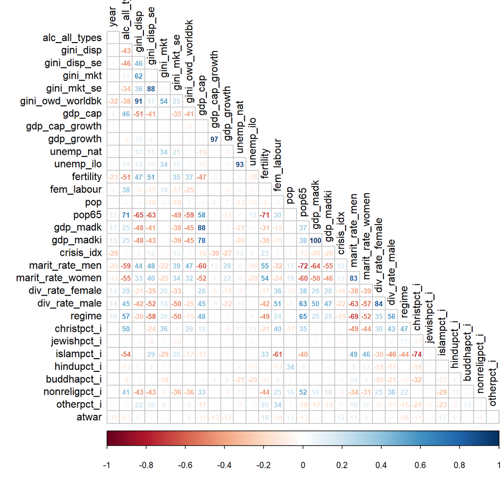

```r
# read in again to be sure it's the original (unedited) data frame
df_raw <- readRDS(here::here("output/joined_raw_owd.Rds"))

corr <- df_raw %>%
  select(-c(starts_with("suicide"), country, iso3c, banking_crisis:inflation_crisis,
            average_household_size_number_of_members:`6_or_more_members`,
            alc_wine, alc_beer, alc_other_alcoholic_beverages, alc_spirits)) %>%
  cor(use = "pairwise.complete.obs")


corr %>% corrplot::corrplot(diag = FALSE, method = "number", type = "lower",
                            addCoefasPercent = TRUE, tl.col = "black", number.cex = .7)
```

#### Based on correlations >.5, following imputations might be adequate:

```r
# variables to impute
to_impute <- c("fertility", "marit_rate_men", "marit_rate_women", "div_rate_male", "div_rate_female")

corr_list <-
  # enter to be imputed values here
  map(to_impute,
      # put variables and values with corr. >.5 into tibbles
      ~ corr[.x,] %>%
        subset(abs(.)>=.5) %>%
        round(2) %>%
        paste(names(.), .) %>%
        tibble()) %>%
  # set names of tibbles
  imap(~setNames(.x, to_impute[.y])) %>%
  # create rowname variable for joining
  map(rownames_to_column) %>%
  # reduce list to one data frame by joining all tibbles
  reduce(full_join, by = "rowname") %>%
  select(-rowname) %>%
  # replace NA with empty strings
  mutate(across(everything(), ~replace_na(., "")))

corr_list %>%
  kable() %>%
  kable_classic()
```

| fertility | marit_rate_men | marit_rate_women | div_rate_male | div_rate_female |
| --- | --- | --- | --- | --- |
| alc_all_types -0.51 | alc_all_types -0.59 | alc_all_types -0.55 | gini_disp_se -0.52 | div_rate_female 1 |
| gini_disp_se 0.51 | gdp_cap -0.6 | gdp_cap -0.52 | fem_labour 0.51 | div_rate_male 0.84 |
| fertility 1 | fertility 0.55 | fertility 0.54 | pop65 0.63 |  |
| pop65 -0.71 | pop65 -0.72 | pop65 -0.6 | marit_rate_men -0.63 |  |
| marit_rate_men 0.55 | gdp_madk -0.64 | gdp_madk -0.5 | marit_rate_women -0.57 |  |
| marit_rate_women 0.54 | gdp_madki -0.55 | marit_rate_men 0.83 | div_rate_female 0.84 |  |
|  | marit_rate_men 1 | marit_rate_women 1 | div_rate_male 1 |  |
|  | marit_rate_women 0.83 | div_rate_male -0.57 | regime 0.56 |  |
|  | div_rate_male -0.63 | regime -0.52 |  |  |
|  | regime -0.69 |  |  |  |